# (House Prices)

## Preliminary Wrangling

> This document explores a dataset containing prices and attributes for approximately 6029 houses.

```python
# import all packages and set plots to be embedded inline
import numpy as np
import pandas as pd
import matplotlib.pyplot as plt
import seaborn as sb

%matplotlib inline
```

```python
# load in the dataset into a pandas dataframe, print statistics
houses= pd.read_csv('house_prices.csv',encoding ='utf-8')
houses.head()
```

|  | house_id | neighborhood | area | bedrooms | bathrooms | style | price |
| --- | --- | --- | --- | --- | --- | --- | --- |
| 0 | 1112 | B | 1188 | 3 | 2 | ranch | 598291 |
| 1 | 491 | B | 3512 | 5 | 3 | victorian | 1744259 |
| 2 | 5952 | B | 1134 | 3 | 2 | ranch | 571669 |
| 3 | 3525 | A | 1940 | 4 | 2 | ranch | 493675 |
| 4 | 5108 | B | 2208 | 6 | 4 | victorian | 1101539 |

```python
# high-level overview of data shape and composition
print(houses.shape)
print(houses.dtypes)
print(houses.neighborhood.value_counts())
print(houses['style'].value_counts())
```

```
(6028, 7)
house_id         int64
neighborhood    object
area             int64
bedrooms         int64
bathrooms        int64
style           object
price            int64
dtype: object
B    2427
A    1876
C    1725
Name: neighborhood, dtype: int64
victorian    2997
ranch        1802
lodge        1229
Name: style, dtype: int64
```

```python
# Summary Statistics
print(houses.describe(include=['object']))
houses.describe()
```

```
       neighborhood      style
count          6028       6028
unique            3          3
top               B  victorian
freq           2427       2997
```

|  | house_id | area | bedrooms | bathrooms | price |
| --- | --- | --- | --- | --- | --- |
| count | 6028.000000 | 6028.000000 | 6028.000000 | 6028.000000 | 6.028000e+03 |
| mean | 4110.536828 | 2136.849038 | 3.717651 | 2.158261 | 7.542079e+05 |
| std | 2251.834665 | 1237.481101 | 1.704650 | 1.169621 | 5.236731e+05 |
| min | 200.000000 | 0.000000 | 0.000000 | 0.000000 | 1.216700e+04 |
| 25% | 2167.500000 | 1225.000000 | 3.000000 | 2.000000 | 3.641350e+05 |
| 50% | 4120.500000 | 1826.000000 | 4.000000 | 2.000000 | 6.357590e+05 |
| 75% | 6070.250000 | 3129.000000 | 5.000000 | 3.000000 | 9.666752e+05 |
| max | 7999.000000 | 7447.000000 | 8.000000 | 5.000000 | 3.684602e+06 |

```python
#putting the houses price in thoushand $ unit
houses.price=houses.price/1000
```

```python
# convert Neighborhood into ordered categorical types
ordinal_var_dict = {'neighborhood': ['A','B','C']}

ordered_var = pd.api.types.CategoricalDtype(ordered = True,
                                                categories = ordinal_var_dict['neighborhood'])
houses['neighborhood'] = houses['neighborhood'].astype(ordered_var)
```

### What is/are the main feature(s) of interest in your dataset?

I'm most interested in figuring out what features are best for predicting the price of the houses in the dataset.

### What features in the dataset do you think will help support your investigation into your feature(s) of interest?

I expect that area will have the strongest effect : the larger the area, the larger the price. I also think that the other big contribute to the price will be the number of bedrooms, and the neighboorhood

## Univariate Exploration

> I'll start by looking at the distribution of price and the main variable of interest: price. .

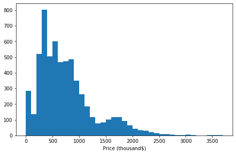

```python
# start with a standard-scaled plot
binsize = 100
bins = np.arange(0, houses['price'].max()+binsize, binsize)

plt.figure(figsize=[8, 5])
plt.hist(data = houses, x = 'price', bins = bins)
plt.xlabel('Price (thousand$)')
plt.show()
```

There's a very long tail of prices with view points after 2500 K$. Here, I will zoom to the area from 0 to 2500 to get a more detailed look about the distribution and avoiding extreme or outliers points

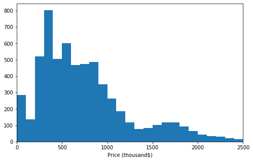

```python
plt.figure(figsize=[8, 5])
plt.hist(data = houses, x = 'price', bins = bins)
plt.xlabel('Price (thousand$)')
##Ignoring the tail
plt.xlim((0,2500))
plt.show()
```

> Prices is positively skewed to the right

Next we will look in the area distribution

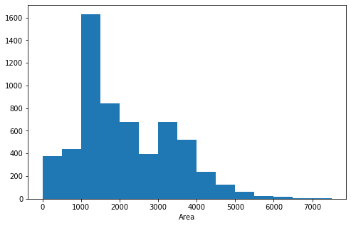

```python
# plotting Area on a standard scale
binsize = 500
bins = np.arange(0, houses['area'].max()+binsize, binsize)

plt.figure(figsize=[8, 5])
plt.hist(data = houses, x = 'area', bins = bins)
plt.xlabel('Area')
plt.show()
```

> Let's Zoom in the area range below 5000 And ignore the tail

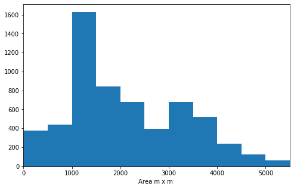

```python
plt.figure(figsize=[8, 5])
plt.hist(data = houses, x = 'area', bins = bins)
plt.xlabel('Area m x m ')
plt.xlim((0,5500))

plt.show()
```

> The Area mostly distributed under 5000 meter square

Let's look next into the neighborhood

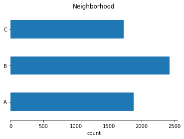

```python
houses['neighborhood'].value_counts().sort_index().plot(kind='barh' )
plt.title('Neighborhood')
#plt.ylabel('Neighborhood')
plt.xlabel('count');
sb.despine(left=True, right=True)
```

> Most houses are in neighborhood B

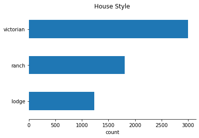

```python
houses['style'].value_counts().sort_index().plot(kind='barh' )
plt.title('House Style')

plt.xlabel('count');
sb.despine(left=True, right=True)
```

> Most houses are of victorian style almost half of the dataset, the second most syle are ranch and the least style are lodge

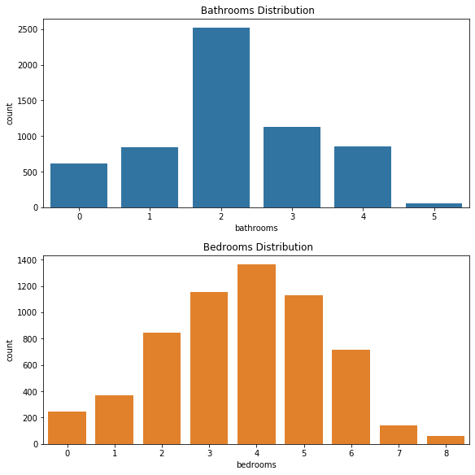

```python
fig, ax = plt.subplots(nrows=2, figsize = [8,8],constrained_layout=True)

default_color_1 = sb.color_palette()[0]
default_color_2 = sb.color_palette()[1]
sb.countplot(data = houses, x = 'bathrooms', color = default_color_1, ax = ax[0])
sb.countplot(data = houses, x = 'bedrooms', color = default_color_2, ax = ax[1])
ax[0].set_title(' Bathrooms Distribution')
ax[1].set_title(' Bedrooms Distribution')


plt.show()
```

> Most houses have two bathrooms and there are houses of lodge style without bathrooms  
> Most houses in the dataset also has multiple bedrooms 3,4 or 5 are most common

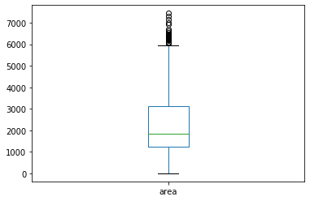

```python
ax =houses.area.plot.box()
```

```python
area_outlier_index=houses[houses['area']>=6100].index
houses.drop(area_outlier_index,inplace=True)
```

```python
houses.shape
```

```
(6005, 7)
```

### Discuss the distribution(s) of your variable(s) of interest. Were there any unusual points? Did you need to perform any transformations?

> The price has a high range of values and can be experessed in thousand dollar instead of dollar for simplicity The neighborhood consists of 3 neighborhood and converted to ordinal category A,B and C

### Of the features you investigated, were there any unusual distributions? Did you perform any operations on the data to tidy, adjust, or change the form of the data? If so, why did you do this?

> We have a view outlier point of area above 6100 with also high prices that can bias the analysis so they are removed using boxplot this point was confirmed

## Bivariate Exploration

> In this section, investigate relationships between pairs of variables in your data. Make sure the variables that you cover here have been introduced in some fashion in the previous section (univariate exploration).

```python
numeric_vars = ['price', 'bedrooms', 'bathrooms', 'area']
categoric_vars = ['style', 'neighborhood']
```

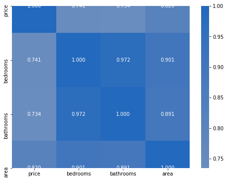

```python
# correlation plot
plt.figure(figsize = [8, 6])
sb.heatmap(houses[numeric_vars].corr(), annot = True, fmt = '.3f',
           cmap = 'vlag_r', center = 0)
plt.show()
```

> Area is the highest correlated variable with price 0.820  
> Number of bedrooms has slightly more impact on price than # of bathrooms

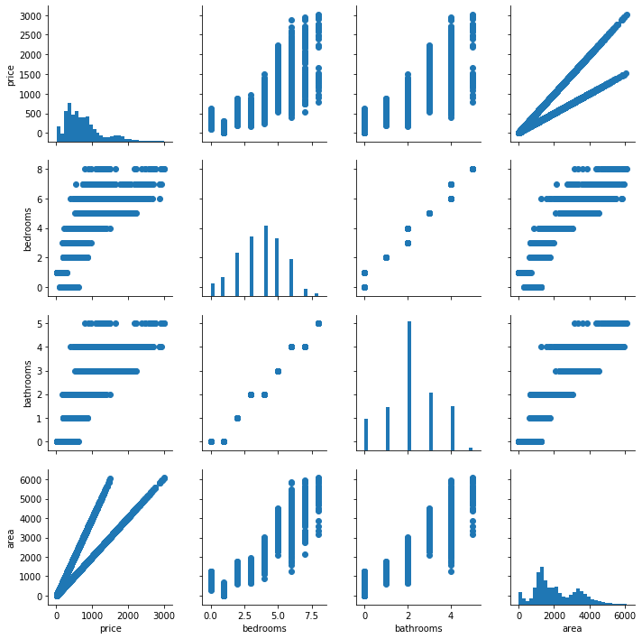

```python
# plot matrix:
plt.figure(figsize = [20, 20])

g = sb.PairGrid(data = houses, vars = numeric_vars)
g = g.map_diag(plt.hist, bins = 30);
g.map_offdiag(plt.scatter)
```

> Strong correaltion between price and area Strong correlation between number of bedrooms and number of bathrooms

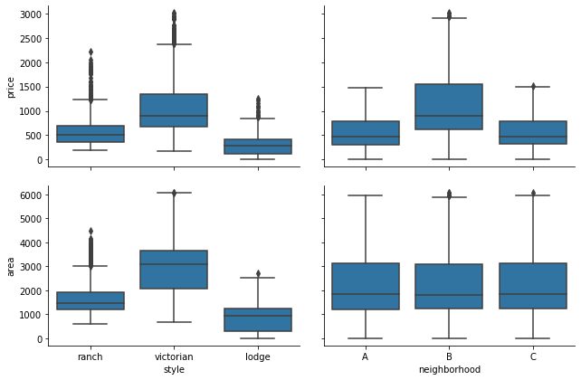

```python
# plot matrix of numeric features against categorical features.
# can use a larger sample since there are fewer plots and they're simpler in nature.


def boxgrid(x, y, **kwargs):
    """ Quick hack for creating box plots with seaborn's PairGrid. """
    default_color = sb.color_palette()[0]
    sb.boxplot(x, y, color = default_color)

plt.figure(figsize = [10, 10])
g = sb.PairGrid(data = houses, y_vars = ['price','area'], x_vars = categoric_vars,
                height = 3, aspect = 1.5)
g.map(boxgrid)
plt.show();
```

> Area destribution is not different in different neighborhood  
> Victorian houses has the highest prices  
> Neighborhood B has higher prices

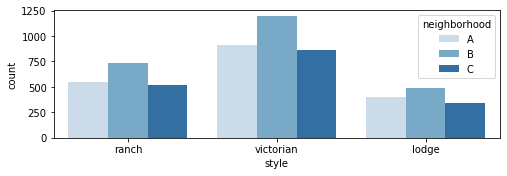

```python
plt.figure(figsize = [8, 8])

# subplot 1: style vs neighborhood
plt.subplot(3, 1, 1)
sb.countplot(data = houses, x = 'style', hue = 'neighborhood', palette = 'Blues')

plt.show()
```

> Neighborhood B has more houses than other areas and also has its most style of houses as victorian houses

Let's plot the violin chart for price and area against categorical variables

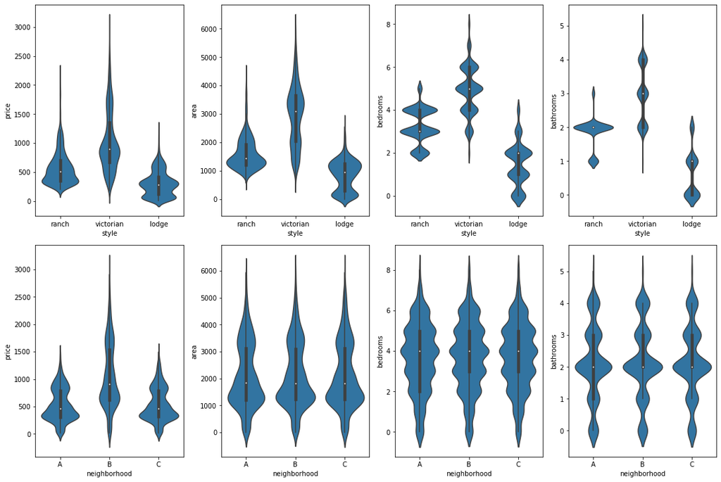

```python
# plot the categorical variables against price and area ,bedrooms and bathrooms
fig, ax = plt.subplots(ncols = 4, nrows = 2 , figsize = [15,10],constrained_layout=True)
default_color = sb.color_palette()[0]

for i in range(len(categoric_vars)):
    var = categoric_vars[i]
    sb.violinplot(data = houses, x = var, y = 'price', ax = ax[i,0],
               color = default_color)
    sb.violinplot(data = houses, x = var, y = 'area', ax = ax[i,1],
               color = default_color)
    sb.violinplot(data = houses, x = var, y = 'bedrooms', ax = ax[i,2],
               color = default_color)
    sb.violinplot(data = houses, x = var, y = 'bathrooms', ax = ax[i,3],
               color = default_color)

plt.show()
```

> Lodge houses are small in area, while victorian houses have a larger area  
> Neighborhood B prices are more distributed ,and the 3 neighborhood has same area distribution  
> Victorian has higher number of bedrooms and bathrooms and lodge has the least of them

### Talk about some of the relationships you observed in this part of the investigation. How did the feature(s) of interest vary with other features in the dataset?

> Strong correlation between price and Area Price also increases with number of bathrooms and bedrooms which might be dirctly related to increase of area Area distribution isn't different among neighborhood Lodge houses seems to have the least price and least areas Neighborhood B has higher prices than A and C neighborhoods

### Did you observe any interesting relationships between the other features (not the main feature(s) of interest)?

> Number of bedrooms and bathrooms seems to be closely related (positive correlation) Victorian sytle houses have the largest area

## Multivariate Exploration

> Create plots of three or more variables to investigate your data even further.

Let's look into the effect of neighborhood and house style on prices together

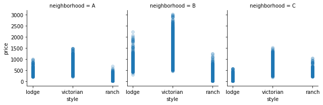

```python
    neighborhood=['A','B','C']
    pd_ver = pd.__version__.split(".")
    if (int(pd_ver[0]) > 0) or (int(pd_ver[1]) >= 21): # v0.21 or later
        vclasses = pd.api.types.CategoricalDtype(ordered = True, categories = neighborhood)
        houses['nieghborhood'] = houses['neighborhood'].astype(vclasses)
    else: # compatibility for v.20
        houses['neighborhood'] = houses['VClass'].astype('category', ordered = True,
                                                         categories = neighborhood)

    # plotting
    g = sb.FacetGrid(data = houses, col = 'neighborhood', size = 3, col_wrap = 3)
    g.map(plt.scatter, 'style', 'price', alpha = 1/5);
```

Houses in neighborhood B with victorian style is the highest in price

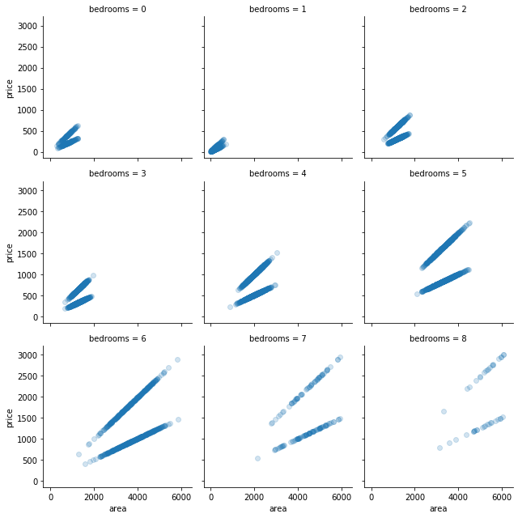

```python
    # plotting
    #Treating bedrooms as categorical
    bedrooms=[0,1,2,3,4,5,6,7,8]
    pd_ver = pd.__version__.split(".")
    if (int(pd_ver[0]) > 0) or (int(pd_ver[1]) >= 21): # v0.21 or later
        vclasses = pd.api.types.CategoricalDtype(ordered = True, categories = bedrooms)
        houses['bedrooms'] = houses['bedrooms'].astype(vclasses)
    else: # compatibility for v.20
        houses['bedrooms'] = houses['VClass'].astype('category', ordered = True,
                                                         categories = bedrooms)
    g = sb.FacetGrid(data = houses, col = 'bedrooms', size = 3, col_wrap = 3)
    g.map(plt.scatter, 'area', 'price', alpha = 1/5);
```

For the same area number of bedrooms gives a higher price

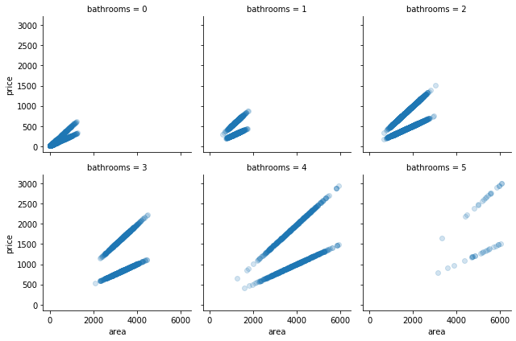

```python
    # plotting
    #Treating bathrooms as categorical
    bathrooms=[0,1,2,3,4,5]
    pd_ver = pd.__version__.split(".")
    if (int(pd_ver[0]) > 0) or (int(pd_ver[1]) >= 21): # v0.21 or later
        vclasses = pd.api.types.CategoricalDtype(ordered = True, categories = bathrooms)
        houses['bathrooms'] = houses['bathrooms'].astype(vclasses)
    else: # compatibility for v.20
        houses['bedrooms'] = houses['VClass'].astype('category', ordered = True,
                                                         categories = bedrooms)
    g = sb.FacetGrid(data = houses, col = 'bathrooms', size = 3, col_wrap = 3)
    g.map(plt.scatter, 'area', 'price', alpha = 1/5);
```

> For the same the increase in number of bathrooms increases price

### Talk about some of the relationships you observed in this part of the investigation. Were there features that strengthened each other in terms of looking at your feature(s) of interest?

> There is a clear effect of number of bedrooms and number of bathrooms in the price There is a clear relationship between neighborhood and house style and increase in price as neighborhood B ,style victorian has higher price

### Were there any interesting or surprising interactions between features?

> The effect of bathrooms and bedrooms in increas of the price

> At the end of your report, make sure that you export the notebook as an html file from the `File > Download as... > HTML` menu. Make sure you keep track of where the exported file goes, so you can put it in the same folder as this notebook for project submission. Also, make sure you remove all of the quote-formatted guide notes like this one before you finish your report!